# Answer key for HW3 CDA

TA-Liu Lirong

2019年11月9日

> GDS5037 (15 points)

```r
library(stringr)   # 使用提取函数
library(dplyr)     # 用导管运算
data=read.csv('C:\\Users\\liulirong\\Desktop\\CDA本科助教\\GDS5037\\GDS5037.csv',
              encoding='UTF-8',header=TRUE)       # 读取数据
```

```r
# 提取字符串
patients=data[51:158,1] %>% as.character()
keys="MMA|control|SA"
patients_status=patients %>% str_extract(keys)
Y=ifelse(patients_status=="control",0,1)
X=t(data[162,-c(1,2)]) %>% as.numeric()
data0=data.frame(Y,X)
```

(a). (7 points)

```r
# logistic model
fit1=glm(Y~X,data=data0,family=binomial(link='logit'))
summary(fit1)
```

```
##
## Call:
## glm(formula = Y ~ X, family = binomial(link = "logit"), data = data0)
##
## Deviance Residuals:
##     Min       1Q   Median       3Q      Max
## -1.8625   0.6241   0.6350   0.6478   0.6736
##
## Coefficients:
##             Estimate Std. Error z value Pr(>|z|)
## (Intercept)   2.2352     3.7822   0.591    0.555
## X            -0.1245     0.6228  -0.200    0.842
##
## (Dispersion parameter for binomial family taken to be 1)
##
##     Null deviance: 103.50  on 107  degrees of freedom
## Residual deviance: 103.46  on 106  degrees of freedom
## AIC: 107.46
##
## Number of Fisher Scoring iterations: 4
```

Model:
$$log \frac{P(Y=1)}{P(Y=0)}=2.2352-0.1245\times AP3S2$$
since $\hat\beta=-0.1245<0$,$P(Y=1)$ decrease as AP3S2 increase.

(b). (8 points)

```r
# probit model
fit2=glm(Y~X,data=data0,family=binomial(link='probit'))
summary(fit2)
```

```
##
## Call:
## glm(formula = Y ~ X, family = binomial(link = "probit"), data = data0)
##
## Deviance Residuals:
##     Min       1Q   Median       3Q      Max
## -1.8632   0.6237   0.6349   0.6481   0.6742
##
## Coefficients:
##             Estimate Std. Error z value Pr(>|z|)
## (Intercept)  1.33171    2.13207   0.625    0.532
## X           -0.07202    0.35134  -0.205    0.838
##
## (Dispersion parameter for binomial family taken to be 1)
##
##     Null deviance: 103.50  on 107  degrees of freedom
## Residual deviance: 103.46  on 106  degrees of freedom
## AIC: 107.46
##
## Number of Fisher Scoring iterations: 4
```

Model:
$$probit(P(Y=1))=1.33171-0.07202\times AP3S2$$
since $\hat\beta=-0.07202<0$,$P(Y=1)$ decrease as AP3S2 increase.

> Problem 3.3 (15 points)

(a). (7 points)  
$\hat \pi=0.00255+0.00109x$  
Intercept means when mother’s alcohol consumption is 0, the probability of malformation is 0.25%. Slope means when mother’s alcohol consumption increases one, probability of malformation will increases 0.11%.  
(b). (8 points) When $x=0,\hat \pi_{2}=0.00255+0.00109×0=0.00255$  
When $x =7,\hat \pi_{2}=0.00255+0.00109×7=0.01018$  
The relative risk $=\frac{\pi_{1}}{\pi_{2}}=\frac{0.01018}{0.00255}=3.99$

> Problem 3.9 (15 points)

(a). (5 points)
$$log \frac{\hat \pi}{1-\hat \pi}=-3.5561+0.0532\times Income$$
(b). (5 points) $\hat \beta=0.0532>0$,which means that the probability of possessing a travel credit card increase as income increase.
(c). (5 points)
When $\hat \pi=0.50$,the estimated logit value is $log\frac{0.5}{1-0.5}=log(1)=0$.
When $Income=66.86$,by solving
$$log \frac{\hat \pi}{1-\hat \pi}=-3.5561+0.0532\times 66.86=0.000852$$
we can get $\hat \pi=\frac{e^{0.000852}}{1+e^{0.000852}}=0.5$

> Problem 3.11 (20 points)

(a). (5 points) For treatment A:
$$log \mu_{A}=\alpha$$
For treatment B:
$$log \mu_{B}=\alpha+\beta$$
So we have
$$\beta=log\mu_{B}-log \mu_{A}$$
which is equivalent to
$$e^{\beta}=\frac{\mu_{B}}{\mu_{A}}$$
(b). (5 points)

```r
library(cdabookdb)
library(cdabookfunc)
```

```r
chip_imperfection$Treatment=as.numeric(chip_imperfection$Treatment)-1
fit=glm(Imperfections~Treatment,data=chip_imperfection,family=poisson(link='log'))
summary(fit)
```

```
##
## Call:
## glm(formula = Imperfections ~ Treatment, family = poisson(link = "log"),
##     data = chip_imperfection)
##
## Deviance Residuals:
##     Min       1Q   Median       3Q      Max
## -1.5280  -0.7622  -0.1699   0.6938   1.5399
##
## Coefficients:
##             Estimate Std. Error z value Pr(>|z|)
## (Intercept)   1.6094     0.1414  11.380  < 2e-16 ***
## Treatment     0.5878     0.1764   3.332 0.000861 ***
## ---
## Signif. codes:  0 '***' 0.001 '**' 0.01 '*' 0.05 '.' 0.1 ' ' 1
##
## (Dispersion parameter for poisson family taken to be 1)
##
##     Null deviance: 27.857  on 19  degrees of freedom
## Residual deviance: 16.268  on 18  degrees of freedom
## AIC: 94.349
##
## Number of Fisher Scoring iterations: 4
```

(c). (7 points) Testing $H_{0}:\mu_{A}=\mu_{B}$ is equivalent to $\beta=0$ (c.1).
Wald Test: From the results in (b),we know $z=3.33,z^2=11.1$ and $P<0.001$,so reject the null hypothesis,and $\beta \neq0$,further,$\beta>0$,which means the treatment B has higher defective rate. (c.2).
LR Test: $LR=-2log(l_0/l_1)=-2[log(l_0)-log(l_1)]=11.6$,and $df=1$,then we can calculate $P=1-pchisq(11.6,1)<0.001$,so reject the null hypothesis,and $\beta \neq0$,further,$\beta>0$,which means the treatment B has higher defective rate.
(d). (3 points)
The 95% cI of $\beta$ is:
$$(0.5878\pm1.96\times 0.1764)=(0.2421,0.9335)$$
so,the 95% CI of $\frac{\mu{B}}{\mu{A}}$ is $(1.2739,2.5435)$.

> Problem 3.18 (20 points)

(a). (5 points)
$E(Y)=\mu t$ since Y follows a Poisson distribution.
The model is:
$$E(Y)=\mu t \\ \Rightarrow log[E(Y)]=log(\mu t) \\ \Rightarrow log[E(Y)/t]=log(\mu) \\ \Rightarrow log[E(Y)/t]=\alpha$$
where $\alpha=log(\mu)$.
And the the form with intercpt is $log[E(Y)]=\alpha+log(t)$.

(b). (5 points)

```r
fit1=glm(Arrests~1,data=football_arrest,family=poisson(link='log'),offset=log(Attendance))
summary(fit1)
```

```
##
## Call:
## glm(formula = Arrests ~ 1, family = poisson(link = "log"), data = football_arrest,
##     offset = log(Attendance))
##
## Deviance Residuals:
##     Min       1Q   Median       3Q      Max
## -12.789   -3.426   -0.938    3.079   10.137
##
## Coefficients:
##             Estimate Std. Error z value Pr(>|z|)
## (Intercept) -0.91028    0.02164  -42.07   <2e-16 ***
## ---
## Signif. codes:  0 '***' 0.001 '**' 0.01 '*' 0.05 '.' 0.1 ' ' 1
##
## (Dispersion parameter for poisson family taken to be 1)
##
##     Null deviance: 669.45  on 22  degrees of freedom
## Residual deviance: 669.45  on 22  degrees of freedom
## AIC: 812.62
##
## Number of Fisher Scoring iterations: 5
```

According the results,we have $\hat \alpha=-0.9103$,so $\hat \mu=exp(\hat \alpha)=0.4024$,which means that when the one more attendance,the expectation of arrests increase 0.4024 unit average.

(c). (5 points)

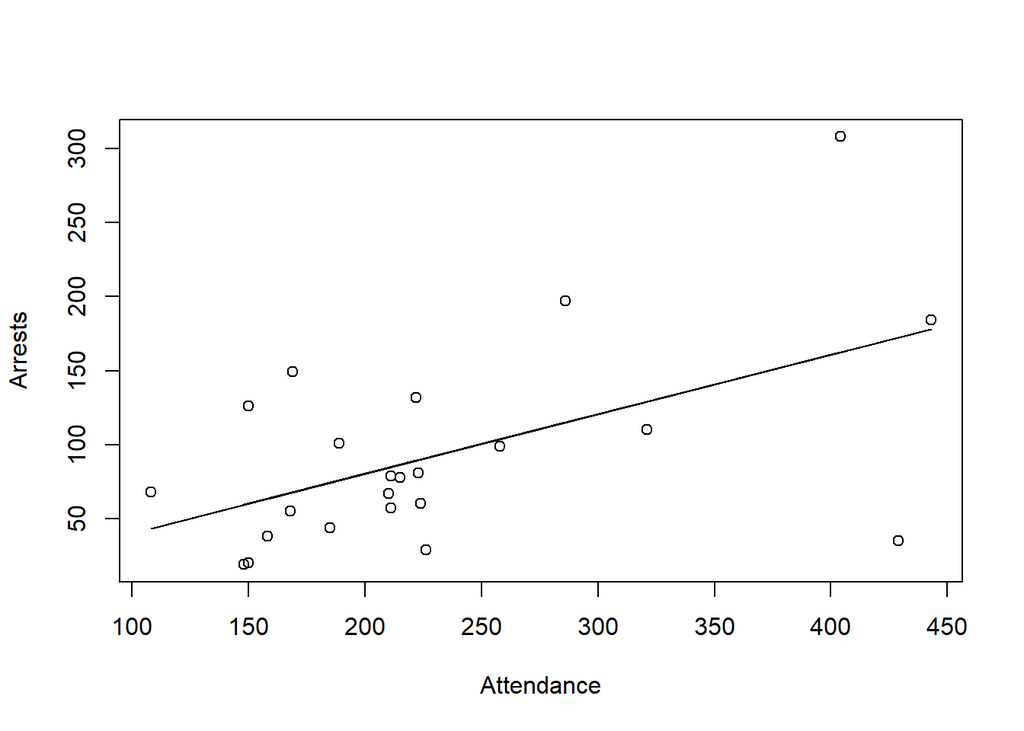

```r
Attendance=football_arrest$Attendance
Arrests=football_arrest$Arrests
plot(Attendance,Arrests)
lines(Attendance,fitted.values(fit1),type='l')
```

```r
res=fit1$residuals
paste('The team whose arrests bigger than the expectation:')
```

```
## [1] "The team whose arrests bigger than the expectation:"
```

```r
football_arrest[which(res>0),1]
```

```
## [1]   Aston Villa     Shrewsbury      Bradford City   Leeds United
## [5]   Bournemouth     West Brom       Hudderfield     Birmingham
## 23 Levels:   Aston Villa   Barnsley   Birmingham ...   West Brom
```

```r
paste('The team whose arrests smaller than the expectation:')
```

```
## [1] "The team whose arrests smaller than the expectation:"
```

```r
football_arrest[which(res<0),1]
```

```
##  [1]   Swindon Town      Sheffield Utd     Stoke City
##  [4]   Barnsley          Millwall          Middlesbro
##  [7]   Hull City         Manchester City   Ipswich Town
## [10]   Plymouth          Leicester City    Reading
## [13]   Blackburn         Oldham            Crystal Palace
## 23 Levels:   Aston Villa   Barnsley   Birmingham ...   West Brom
```

(d). (5 points)

```r
library(MASS)
fit2=glm.nb(Arrests~offset(log(Attendance)))
summary(fit2)
```

```
##
## Call:
## glm.nb(formula = Arrests ~ offset(log(Attendance)), init.theta = 3.135631071,
##     link = log)
##
## Deviance Residuals:
##     Min       1Q   Median       3Q      Max
## -2.2049  -0.7464  -0.1857   0.6129   1.5568
##
## Coefficients:
##             Estimate Std. Error z value Pr(>|z|)
## (Intercept)  -0.9052     0.1200  -7.546 4.49e-14 ***
## ---
## Signif. codes:  0 '***' 0.001 '**' 0.01 '*' 0.05 '.' 0.1 ' ' 1
##
## (Dispersion parameter for Negative Binomial(3.1356) family taken to be 1)
##
##     Null deviance: 24.15  on 22  degrees of freedom
## Residual deviance: 24.15  on 22  degrees of freedom
## AIC: 244.24
##
## Number of Fisher Scoring iterations: 1
##
##
##               Theta:  3.136
##           Std. Err.:  0.920
##
##  2 x log-likelihood:  -240.236
```

For the possion model:$\hat \mu=exp(-0.91)=0.4$,which is similar to the nb model.But comparing AIC,the possion is bigger than the nb model.So,the nb model is more appropriate.